# ML Final Project

## Classifying Pokémon Images with Machine Learning

### Zoey Chen

Data: https://www.kaggle.com/datasets/vishalsubbiah/pokemon-images-and-types?resource=download

Rubric: There is a class project that is done by each students. The purpose of the project is to test the students’ ability to apply the machine learning techniques and tools presented in the class to diverse practical problems and interpret & apply the results. The class project covers: • Choose a real-world machine learning problem with an objective • Procure and analyze the data • Develop at a deep learning or recommender system model • Outline data / model assumptions & limitations / hypotheses • Evaluate model metrics such as overfitting / underfitting • Select final model based on selection criteria • Determine how the model can be improved • Effectively communicate analytical work For the class project, students are graded on 8 criteria outlined below. Each criterion is 5 points for a total of 40 points. The criteria are:

1. Problem Statement
2. Assumptions/Hypotheses about data and model
3. Exploratory Data Analysis
4. Feature Engineering & Transformations
5. Proposed Approaches (Model) with checks for overfitting/underfitting
6. Proposed Solution (Model Selection) with regularization, if needed
7. Results (Accuracy) and Learnings from the methodology
8. Future Work

## load the data

```python
#import libraries
import numpy as np
import pandas as pd
import seaborn as sns
from matplotlib import pyplot as plt
import matplotlib.image as mpimg
import zipfile
import os
from pathlib import Path
import re
import tensorflow as tf
from tensorflow import keras
from keras import layers
```

```
2023-05-22 15:20:18.993027: I tensorflow/core/platform/cpu_feature_guard.cc:182] This TensorFlow binary is optimized to use available CPU instructions in performance-critical operations.
To enable the following instructions: AVX2 FMA, in other operations, rebuild TensorFlow with the appropriate compiler flags.
```

```python
import warnings
warnings.filterwarnings("ignore")
```

```python
# create a path to the pokemon image directory
train_dir = '/Users/zoey/Desktop/ML final project/pokemons_images'
train_path = Path(train_dir)

# create a dataframe with the name and filepath of each pokemon
files = list(train_path.glob('*.png'))
names = [os.path.split(x)[1] for x in list(train_path.glob('*.png'))]
image_df = pd.concat([pd.Series(names, name='Name'), pd.Series(files, name='Filepath').astype(str)], axis=1)
image_df['Name'] = image_df['Name'].apply(lambda x: re.sub(r'\.\w+$', '', x))
image_df.head()

# load in csv with the name, primary type, and secondary type of each pokemon
label_df = pd.read_csv('pokemon.csv')
```

```python
label_df
```

|  | Name | Type1 | Type2 |
| --- | --- | --- | --- |
| 0 | bulbasaur | Grass | Poison |
| 1 | ivysaur | Grass | Poison |
| 2 | venusaur | Grass | Poison |
| 3 | charmander | Fire | NaN |
| 4 | charmeleon | Fire | NaN |
| ... | ... | ... | ... |
| 804 | stakataka | Rock | Steel |
| 805 | blacephalon | Fire | Ghost |
| 806 | zeraora | Electric | NaN |
| 807 | meltan | Steel | NaN |
| 808 | melmetal | Steel | NaN |

809 rows × 3 columns

```python
na_count = label_df['Type2'].isna().sum()
print("Number of NA values in Type2:", na_count)
```

```
Number of NA values in Type2: 404
```

```python
# merge image_df with label_df
df = image_df.merge(label_df, on='Name')

df.head()
```

|  | Name | Filepath | Type1 | Type2 |
| --- | --- | --- | --- | --- |
| 0 | parasect | /Users/zoey/Desktop/ML final project/pokemons_... | Bug | Grass |
| 1 | lumineon | /Users/zoey/Desktop/ML final project/pokemons_... | Water | NaN |
| 2 | raikou | /Users/zoey/Desktop/ML final project/pokemons_... | Electric | NaN |
| 3 | dedenne | /Users/zoey/Desktop/ML final project/pokemons_... | Electric | Fairy |
| 4 | pyroar | /Users/zoey/Desktop/ML final project/pokemons_... | Fire | Normal |

## custome colors + EDA

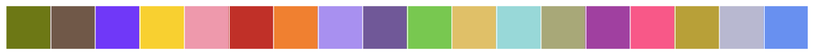

```python
custom_colors = {
    'Bug': '#6d7815',
    'Dark': '#705848',
    'Dragon': '#7038f8',
    'Electric': '#f8d030',
    'Fairy': '#ee99ac',
    'Fighting': '#c03028',
    'Fire': '#f08030',
    'Flying': '#a890f0',
    'Ghost': '#705898',
    'Grass': '#78c850',
    'Ground': '#e0c068',
    'Ice': '#98d8d8',
    'Normal': '#a8a878',
    'Poison': '#a040a0',
    'Psychic': '#f85888',
    'Rock': '#b8a038',
    'Steel': '#b8b8d0',
    'Water': '#6890f0'
}

sns.set(font_scale=1.25)
sns.set_palette(sns.color_palette(custom_colors.values()))
sns.palplot(sns.color_palette(custom_colors.values()),size=1)
```

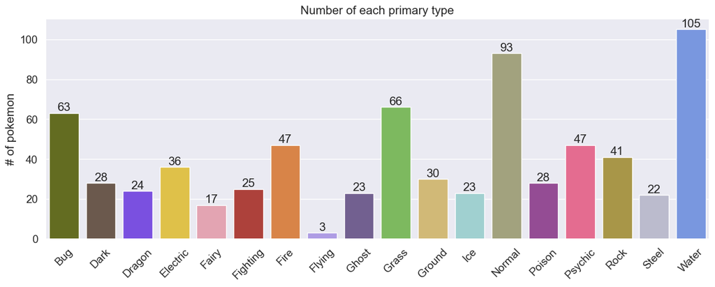

```python
# find the number of each type of pokemon
type1 = list(custom_colors.keys())
type1_nums = []
for type in type1:
  type1_nums.append(sum(df['Type1']==type))

type1_data = pd.DataFrame(data=type1_nums, index=type1, columns=['# of pokemon'])

# plot number of each type of pokemon
plt.figure(figsize=(15,5))
plt.title('Number of each primary type')
ax = sns.barplot(x=type1_data.index, y='# of pokemon', data=type1_data)
ax.set_xticklabels(ax.get_xticklabels(), rotation=45, ha="center")

# Add annotations to the bars
for i, value in enumerate(type1_data['# of pokemon']):
    plt.text(i, value, str(value), ha='center', va='bottom')

plt.show()
```

## check the plots for pokemons and see if there's obvious connections

```python
#To see the variation between primary types, I’ll display one of each primary type of Pokémon:
# determine the indices of the first occurrance of each pokemon type
first_row_indices = []
for type in type1:
  first_row_indices.append(df[df['Type1']==type].index[0])

first_row_indices
```

```
[0, 19, 31, 2, 61, 36, 4, 40, 8, 7, 14, 5, 9, 37, 15, 33, 166, 1]
```

[figure not shown]

```python
# obtain the image from the filepath at the determined indices
imgs = []
for index in first_row_indices:
    file_path = df['Filepath'].iat[index]
    if os.path.isfile(file_path):
        imgs.append(mpimg.imread(file_path))
    else:
        print(f"File not found: {file_path}")

# output the images
f, axarr = plt.subplots(3,6, figsize=(18,9))
count = 0
for r in range(3):
    for c in range(6):
        axarr[r,c].imshow(imgs[count])
        axarr[r,c].set_title(type1[count])
        axarr[r,c].set_axis_off()
        count += 1
plt.show()
```

## display water pokemons

```python
# determine indices for water
w_indices = []
for i in range(len(df.index)):
  if df['Type1'].iat[i]=='Water':
    w_indices.append(i)
```

```python
print(w_indices)
print(len(w_indices))
```

[output not shown]

[figure not shown]

```python
# obtain images from the filepaths at the determined indices
w_imgs = []
for index in w_indices:
    w_imgs.append(mpimg.imread(df['Filepath'].iat[index]))

# output images
f, axarr = plt.subplots(3,6, figsize=(18,9))
count = 0
for r in range(3):
    for c in range(6):
        axarr[r,c].imshow(w_imgs[count])
        axarr[r,c].set_axis_off()
        count += 1
plt.show()


#show first 18 water pokemons
```

## display fire pokemons

```python
# determine indices for fire
f_indices = []
for i in range(len(df.index)):
  if df['Type1'].iat[i]=='Fire':
    f_indices.append(i)
```

```python
print(f_indices)
print(len(f_indices))
```

```
[4, 6, 12, 13, 80, 81, 83, 85, 87, 91, 113, 130, 144, 147, 155, 168, 179, 199, 207, 236, 255, 287, 302, 308, 334, 362, 368, 374, 397, 411, 420, 442, 463, 470, 479, 498, 506, 516, 559, 616, 643, 650, 653, 672, 676, 688, 715]
47
```

[figure not shown]

```python
# obtain images from the filepaths at the determined indices
f_imgs = []
for index in f_indices:
    f_imgs.append(mpimg.imread(df['Filepath'].iat[index]))

# output images
f, axarr = plt.subplots(3,6, figsize=(18,9))
count = 0
for r in range(3):
    for c in range(6):
        axarr[r,c].imshow(f_imgs[count])
        axarr[r,c].set_axis_off()
        count += 1
plt.show()


#show first 18 fire pokemons
```

## feature engineering

```python
# limit data to Fire and Water types
df = df.query("Type1 == 'Fire' | Type1 == 'Water'")

print("Number of water-types:", len(df[df['Type1'] == 'Water']))
print("Number of fire-types:", len(df[df['Type1'] == 'Fire']))
```

```
Number of water-types: 105
Number of fire-types: 47
```

```python
 # shuffle the data
df = df.sample(frac=1).reset_index(drop=True)

train_gen = keras.preprocessing.image.ImageDataGenerator(
    validation_split=0.2,   # split the dataset into a training set and a validation set in an 80:20 ratio
    rescale=1./255          # rescale the rgb values to fit between 0 and 1
)


train_set = train_gen.flow_from_dataframe(
    df,
    x_col='Filepath',
    y_col='Type1',
    target_size=(120, 120),
    color_mode='rgba',
    class_mode='sparse',
    batch_size=32,
    seed=1,
    subset='training'
)

val_set = train_gen.flow_from_dataframe(
    df,
    x_col='Filepath',
    y_col='Type1',
    target_size=(120, 120),
    color_mode='rgba',
    class_mode='sparse',
    batch_size=32,
    seed=1,
    subset='validation'
)
```

```
Found 122 validated image filenames belonging to 2 classes.
Found 30 validated image filenames belonging to 2 classes.
```

#### From the output,there are 122 Pokémon in our training set and 30 Pokémon in our validation set.

## Model training

```python
img_input = layers.Input(shape=(120, 120, 4))

x = layers.Conv2D(filters=64, kernel_size=(8, 8), activation='relu')(img_input)
x = layers.MaxPool2D()(x)

x = layers.Conv2D(filters=128, kernel_size=(8, 8), activation='relu')(x)
x = layers.MaxPool2D()(x)

x = layers.Conv2D(filters=256, kernel_size=(8, 8), activation='relu')(x)
x = layers.MaxPool2D()(x)

x = layers.Flatten()(x)
x = layers.Dense(512, activation='relu')(x)
x = layers.Dropout(0.5)(x)

output = layers.Dense(units=1, activation='sigmoid')(x)

model = keras.Model(inputs=img_input, outputs=output)

model.compile(
    optimizer='adam',
    loss='binary_crossentropy',
    metrics=['acc', keras.metrics.AUC()]
)

# print model layers
model.summary()
```

```
Model: "model_1"
_________________________________________________________________
 Layer (type)                Output Shape              Param #
=================================================================
 input_2 (InputLayer)        [(None, 120, 120, 4)]     0

 conv2d_3 (Conv2D)           (None, 113, 113, 64)      16448

 max_pooling2d_3 (MaxPooling  (None, 56, 56, 64)       0
 2D)

 conv2d_4 (Conv2D)           (None, 49, 49, 128)       524416

 max_pooling2d_4 (MaxPooling  (None, 24, 24, 128)      0
 2D)

 conv2d_5 (Conv2D)           (None, 17, 17, 256)       2097408

 max_pooling2d_5 (MaxPooling  (None, 8, 8, 256)        0
 2D)

 flatten_1 (Flatten)         (None, 16384)             0

 dense_2 (Dense)             (None, 512)               8389120

 dropout_1 (Dropout)         (None, 512)               0

 dense_3 (Dense)             (None, 1)                 513

=================================================================
Total params: 11,027,905
Trainable params: 11,027,905
Non-trainable params: 0
_________________________________________________________________
```

```python
history = model.fit(
    train_set,
    validation_data=val_set,
    batch_size=32,
    epochs=100,
    callbacks=[
        keras.callbacks.EarlyStopping(
            monitor='val_loss',
            patience=3,
            restore_best_weights=True
        ),
        keras.callbacks.ReduceLROnPlateau()
    ]
)
```

```
2023-05-22 15:27:35.862471: I tensorflow/core/common_runtime/executor.cc:1197] [/device:CPU:0] (DEBUG INFO) Executor start aborting (this does not indicate an error and you can ignore this message): INVALID_ARGUMENT: You must feed a value for placeholder tensor 'Placeholder/_0' with dtype int32
	 [[{{node Placeholder/_0}}]]
```

```
2023-05-22 15:27:42.906261: I tensorflow/core/common_runtime/executor.cc:1197] [/device:CPU:0] (DEBUG INFO) Executor start aborting (this does not indicate an error and you can ignore this message): INVALID_ARGUMENT: You must feed a value for placeholder tensor 'Placeholder/_0' with dtype int32
	 [[{{node Placeholder/_0}}]]
```

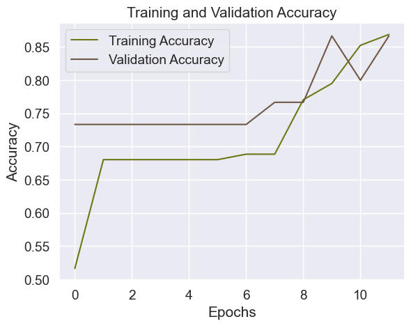

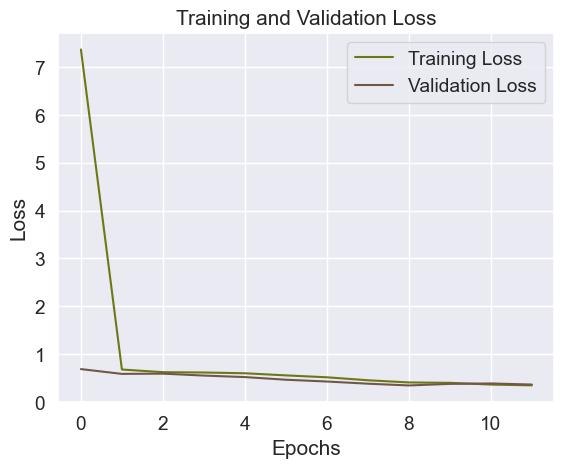

```python
# Retrieve accuracy history on training and validation data
acc = history.history['acc']
val_acc = history.history['val_acc']

# Retrieve loss history on training and validation data
loss = history.history['loss']
val_loss = history.history['val_loss']

# Get number of epochs
epochs = range(len(acc))

# Plot training and validation accuracy per epoch
plt.plot(epochs, acc, label='Training Accuracy')
plt.plot(epochs, val_acc, label='Validation Accuracy')
plt.title('Training and Validation Accuracy')
plt.xlabel('Epochs')
plt.ylabel('Accuracy')
plt.legend()
plt.show()

# Plot training and validation loss per epoch
plt.plot(epochs, loss, label='Training Loss')
plt.plot(epochs, val_loss, label='Validation Loss')
plt.title('Training and Validation Loss')
plt.xlabel('Epochs')
plt.ylabel('Loss')
plt.legend()
plt.show()
```

```python
# get true labels
true_labels = val_set.labels

# get predictions in the form of probablities
predictions = model.predict(val_set)

# convert probablities into binary values
predictions = [1 if n >= 0.5 else 0 for n in predictions]
print("Model predictions: "+str(predictions))
print("Actual labels:     "+str(true_labels))

# determine filepaths of misclassified pokemon
num_misclasssified = 0
misclassified_filepaths = []
correctness = []
for pred, label, i in zip(predictions, true_labels, range(len(predictions))):
  misclassified_filepaths.append(val_set.filepaths[i])
  if pred != label:
    correctness.append('incorrect')
    num_misclasssified += 1
  else:
    correctness.append('correct')

print("# of misclassified pokemon: "+str(num_misclasssified))
```

```
2023-05-22 15:29:22.946876: I tensorflow/core/common_runtime/executor.cc:1197] [/device:CPU:0] (DEBUG INFO) Executor start aborting (this does not indicate an error and you can ignore this message): INVALID_ARGUMENT: You must feed a value for placeholder tensor 'Placeholder/_0' with dtype int32
	 [[{{node Placeholder/_0}}]]
```

```
Model predictions: [1, 1, 1, 1, 1, 1, 1, 1, 1, 1, 1, 1, 1, 1, 1, 1, 1, 1, 1, 1, 1, 1, 1, 1, 1, 0, 1, 1, 1, 1]
Actual labels:     [1, 1, 0, 1, 0, 1, 1, 1, 1, 1, 1, 1, 1, 1, 0, 0, 1, 0, 1, 1, 1, 1, 0, 0, 1, 1, 1, 1, 1, 0]
# of misclassified pokemon: 9
```

[figure not shown]

```python
# obtain the images from the filepath at the determined indices
misclassified_imgs = []
for filepath in misclassified_filepaths:
  misclassified_imgs.append(mpimg.imread(filepath))

# plot results
f, axarr = plt.subplots(6,5, figsize=(20,10))
count = 0
for r in range(6):
  for c in range(5):
    axarr[r,c].imshow(misclassified_imgs[count])
    if correctness[count] == 'correct':
      axarr[r,c].set_title(correctness[count])
    else:
      axarr[r,c].set_title(correctness[count], color='red')
    axarr[r,c].set_axis_off()
    count += 1
plt.show()
```